# Assignment 3: Machine Learning

Pranay Meshram (40280938)

## Introduction

This assignment will focus on the machine learning models to classify between different types of images such as letters, non-letters, finding out the accuracy of models. This assignment will also put focus on cross-validating the data and recording the accuracy.

# Section 1

```r
setwd("C:/Users/Asus/Desktop/AI Assignment")

source("./section1_code.r")
```

Now we will first initially install different libraries as per needed.

We install caTools library for use of splitting samples.

```r
library(caTools)
```

Then we install InformationValue library for use in ConfusionMatrix

```r
library(InformationValue)
```

We install modelr and MLeval library for running our machine learning model.

```r
library(modelr)

library(MLeval)
```

And finally, the ROCR library to plot the ROC curve

```r
library(ROCR)
```

Once we’re set installing the library, we set the seed level to 42 and read all the features from the ‘40280938_features.csv’ file.

```r
features <- read.csv(file = './40280938_features.csv', header = TRUE)

nrow(features)
```

```
[1] 140
```

As we can see, we have 140 rows of data in our features files.

## Section 1.1

Now, we have our data of letters from ‘a’ to ‘j’ and then we have the other non-letters. We can see that from rows 81 till 140, all the images are non-letters.

```r
features[80,]
```

|  | label | index | nr_pix | rows_with_1 | cols_with_1 | rows_with_3p | cols_with_3p | aspect_ratio | neigh_1 | no_neigh_above | no_neigh_below | no_neigh_left | no_neigh_right | no_neigh_horiz | no_neigh_vert | connected_areas | eyes | custom |
| --- | --- | --- | --- | --- | --- | --- | --- | --- | --- | --- | --- | --- | --- | --- | --- | --- | --- | --- |
| 80 | j | 8 | 20 | 8 | 0 | 2 | 2 | 0.2142857 | 4 | 5 | 5 | 13 | 15 | 14 | 4 | 2 | 0 | 0.4487104 |

```r
features[81,]
```

|  | label | index | nr_pix | rows_with_1 | cols_with_1 | rows_with_3p | cols_with_3p | aspect_ratio | neigh_1 | no_neigh_above | no_neigh_below | no_neigh_left | no_neigh_right | no_neigh_horiz | no_neigh_vert | connected_areas | eyes | custom |
| --- | --- | --- | --- | --- | --- | --- | --- | --- | --- | --- | --- | --- | --- | --- | --- | --- | --- | --- |
| 81 | sad | 1 | 20 | 2 | 4 | 1 | 3 | 0.7 | 8 | 9 | 8 | 14 | 13 | 14 | 5 | 4 | 0 | 0.7218321 |

We will create a separate column **isLetter** with two values, 1 and 0. 1 means the image is a letter while 0 means the image is a non-letter.

```r
features$isLetter <- sample(100, size = nrow(features), replace = TRUE)

features$isLetter[1:80] = 1
features$isLetter[81:140] = 0
```

We then split the data into a training set and a test set. We put 80% of the data (0.8) in training set and the rest in test set.

```r
i_split<- sample.split(row.names(features), 0.8)
train<-features[i_split, ]
test<-features[!i_split, ]

nrow(train)
```

```
[1] 112
```

```r
nrow(test)
```

```
[1] 28
```

Once we’re done splitting the data, we fit a logistic regression model using the training data. We try to predict if an image is a letter or not based on **nr_pix** and **aspect_ratio** features of the data.

```r
logistic <- glm(isLetter ~ nr_pix + aspect_ratio, data = train, family="binomial")

logistic
```

```
Call:  glm(formula = isLetter ~ nr_pix + aspect_ratio, family = "binomial",
    data = train)

Coefficients:
 (Intercept)        nr_pix  aspect_ratio
    -1.11646       0.07976      -1.31375

Degrees of Freedom: 111 Total (i.e. Null);  109 Residual
Null Deviance:      154.7
Residual Deviance: 147  AIC: 153
```

Here we an see that there is a very modest change in deviance.

We now predict the probability:

```r
probability = predict(logistic, test, type="response")
probability
```

```
        3         9        18        22        23
0.3075766 0.5421868 0.4805194 0.5907182 0.4141176
       24        25        27        31        32
0.5105085 0.6614199 0.6336151 0.8128797 0.8092850
       41        42        43        44        52
0.5477356 0.6215246 0.6196831 0.5711266 0.6897938
       57        59        65        72        74
0.5745708 0.6111411 0.4016524 0.3826422 0.4653157
       82        87        88        96       103
0.5104017 0.5649869 0.4766168 0.5576699 0.3186762
      115       134       140
0.4673925 0.7034042 0.4209632
```

We now report the confusion matrix for threshold of 0.5:

```r
confusion_matrix <- confusionMatrix(test$isLetter, probability, threshold = 0.5)
confusion_matrix
```

|  | 0 | 1 |
| --- | --- | --- |
| 0 | 3 | 5 |
| 1 | 10 | 10 |

Based on this Confusion Matrix, we can make certain notes:

Here,

```r
accuracy <- (10+3)/28
accuracy
```

```
[1] 0.4642857
```

The accuracy of this model isn’t good as it’s below 50% but closer to it.

**True Positive Rate** - We can calculate the true positive rate by using ‘sensitivity’ function

```r
true_positive_rate <- sensitivity(test$isLetter, probability)
true_positive_rate
```

```
[1] 0.6666667
```

Our model is good predicting if a letter is actually a letter when it’s a letter with positive rate above 50.

**False Positive Rate** - False positive rate is FP / Actual No

```r
false_positive_rate <- (5/8)
false_positive_rate
```

```
[1] 0.625
```

**Precision** - Precision is TP/Predicted Yes

```r
precision <- (10/15)
precision
```

```
[1] 0.6666667
```

**Recall** - Recall is TP/ (TP + FN)

```r
recall <- 10/ (10+10)
recall
```

```
[1] 0.5
```

**F1-Score** - F1 score is (2 * Precision * Recall) / (Precision + Recall)

```r
f1_score <- (2*precision*recall)/(precision+recall)
f1_score
```

```
[1] 0.5714286
```

## Section 1.2

Here we load the caret library first for ‘trainControl’ method to work:

```r
library(caret)
```

Now we are going to perform k-fold cross validation on the previous model. We divide dataset into k groups and then repeat the process k times with each set.

We first perform the cross validation here:

```r
ctrl <- trainControl(method = "cv", number = 5, savePredictions = T)
```

```r
model <- train(isLetter ~ nr_pix + aspect_ratio, data = features, method = "lm", trControl = ctrl)
model
```

```
Linear Regression

140 samples
  2 predictor

No pre-processing
Resampling: Cross-Validated (5 fold)
Summary of sample sizes: 112, 112, 112, 112, 112
Resampling results:

  RMSE       Rsquared    MAE
  0.4886425  0.07429074  0.4673368

Tuning parameter 'intercept' was held constant at
 a value of TRUE
```

Here we can make a few note from the observations.

RSquared is pretty low, which leads to inaccurate predictions as higher the R-Squared, more closely a model predicts actual observations.

Now we predict the probabilities:

```r
probability_cross_validated_data <- predict(model, features)
```

We then make a confusion matrix. Here, we’ll have to unload the caret library first for ‘confusionMatrix’ function to work as some methods of both the libraries are same in name and causees errors.

```r
detach("package:caret", unload = TRUE)

confusionMatrix(features$isLetter, probability_cross_validated_data, threshold = 0.5)
```

|  | 0 | 1 |
| --- | --- | --- |
| 0 | 20 | 18 |
| 1 | 40 | 62 |

```r
NA
NA
```

**Accuracy**

```r
accuracy_cross_validated_data <- (62+20)/140
accuracy_cross_validated_data
```

```
[1] 0.5857143
```

**True Positive Rate**

```r
true_positive_rate_cross_validated_data <- sensitivity(features$isLetter, probability_cross_validated_data)

true_positive_rate_cross_validated_data
```

```
[1] 0.775
```

**False Positive Rate**

```r
false_positive_rate_cross_validated_data <- (18/38)
false_positive_rate_cross_validated_data
```

```
[1] 0.4736842
```

**Precision**

```r
precision_cross_validated_data <- (62/80)
precision_cross_validated_data
```

```
[1] 0.775
```

**Recall**

```r
recall_cross_validated_data <- 62/ (62+40)
recall_cross_validated_data
```

```
[1] 0.6078431
```

**F1-Score**

```r
f1_score_cross_validated_data <- (2*precision_cross_validated_data*recall_cross_validated_data)/(precision_cross_validated_data+recall_cross_validated_data)

f1_score_cross_validated_data
```

```
[1] 0.6813187
```

## Section 1.3

Now we plot the ROC curve for Section 1.2.

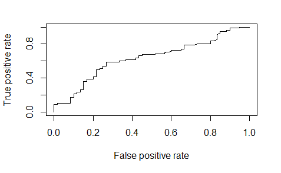

```r
rocr_pred = prediction(probability_cross_validated_data, features$isLetter)

rocr_performance <- performance(rocr_pred, "tpr", "fpr")

plot(rocr_performance)
```

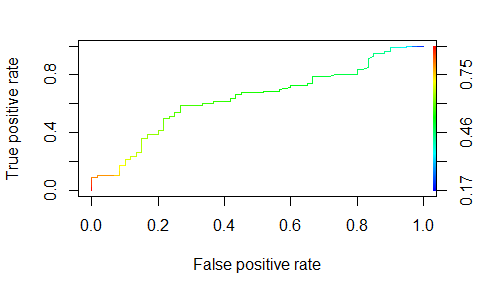

```r
plot(rocr_performance, colorize = TRUE)
```

```r
NA
NA
```

This is a decent classifier, not perfect. It has chance level specificty and sensitivity but it’s not completely straight and with high false positive rate, the true positive rate increases as well.

However since the line is not straight, we can say that our model is not a random classifier. It is a decent classifier but not perfect

# Section 2

## Section 2.2

# Section 3